# STA141A Project

Caitlyn Anne Nunez

2025-03-14

```r
#setting working directory and reading sessions
setwd("/Users/caitlynnunez/Desktop/sta141a project")

session = list()
overview = data.frame(mouse_name = character(), date_exp = character())

for(i in 1:18){
  session[[i]] = readRDS(paste("session", i, '.rds', sep=''))


  overview = rbind(overview, data.frame(mouse_name = session[[i]]$mouse_name, date_exp = session[[i]]$date_exp))
}
```

# Abstract

In this project, the goal is to build a predictive model that can forecast the feedback type of each trial based on neural activity data and the visual stimuli presented to the mice. By analyzing how neural firing patterns relate to the stimuli, the model aims to predict whether the mice will receive a reward or penalty for each decision made during the experiment.

# Introduction

Using 18 sessions from a study done by Steinmetz et al. (2019), we will observe neuron activity in the mice’s visual cortex. The mice made decisions based on visual stimuli with different contrasts, and their choices were rewarded or penalized. The sessions we will be using are from four mice: Lederberg, Frossman, Hence, and Cori. We will analyze the spike train data from these sessions to understand how visual stimuli affect neural firing during decision-making.

# Exploratory Analysis

In this part, I will be exploring the different variables across all of the sessions. By doing so, I can familiarize myself with the data and seeing what variables were in each session. By exploring the data, we can also determine the most notable variables, which will help us answer our overall question and help us build the predictive model.

```r
#function to process the session data
process_session_data <- function(session_data) {
  session_summary <- list()

  for (i in 1:length(session_data)) {
    session <- session_data[[i]]


    feedback_type <- rep(session$feedback_type[1], length(session$spks))

    trial_summary <- tibble(
      session_number = i,
      feedback_type = feedback_type,
      contrast_left = session$contrast_left,
      contrast_right = session$contrast_right,
      time = session$time,
      spks = session$spks,
      brain_area = session$brain_area
    )

    trial_summary <- trial_summary %>%
      mutate(
        total_spks = sum(spks, na.rm = TRUE),
        mean_spks = mean(spks, na.rm = TRUE),
        min_spks = min(spks, na.rm = TRUE),
        max_spks = max(spks, na.rm = TRUE),
        mean_contrast_left = mean(contrast_left, na.rm = TRUE),
        mean_contrast_right = mean(contrast_right, na.rm = TRUE)
      )

    session_summary[[i]] <- trial_summary
  }

  session_all <- bind_rows(session_summary)

  return(session_all)
}
```

```r
#observing feedback types and counts across all sessions
feedback_summary <- lapply(session, function(x) table(x$feedback_type))
print(feedback_summary)

feedback_df <- data.frame(
  Session = rep(1:18, each = 2),
  Feedback_Type = rep(c("Success", "Failure"), times = 18),
  Count = unlist(lapply(feedback_summary, function(x) c(x["1"], x["-1"])))
)

print(feedback_df)
```

```r
#observe all the successes and failures of each trial and a count of each
feedback_summary <- lapply(session, function(x) table(x$feedback_type))
print(feedback_summary)

feedback_df <- data.frame(
  Session = rep(1:18, each = 2),
  Feedback_Type = rep(c("Success", "Failure"), times = 18),
  Count = unlist(lapply(feedback_summary, function(x) c(x["1"], x["-1"])))
)

print(feedback_df)
```

```r
#observe the contrast values for left and right stimuli
contrast_summary_left <- sapply(session, function(x) summary(x$contrast_left))
contrast_summary_right <- sapply(session, function(x) summary(x$contrast_right))

print(contrast_summary_left)
print(contrast_summary_right)

#calculate the mean contrasts for each session
mean_contrast_left <- sapply(session, function(x) mean(x$contrast_left, na.rm = TRUE))
mean_contrast_right <- sapply(session, function(x) mean(x$contrast_right, na.rm = TRUE))


contrast_summary_table <- data.frame(
  Session = 1:18,
  Mean_Contrast_Left = mean_contrast_left,
  Mean_Contrast_Right = mean_contrast_right
)

print(contrast_summary_table)
```

```r
#calculate most important values of spikes per session and create a table for simplicity and readability
total_spks_per_session <- sapply(session, function(x) sum(unlist(x$spks), na.rm = TRUE))


mean_spks_per_session <- sapply(session, function(x) mean(unlist(x$spks), na.rm = TRUE))


min_spks_per_session <- sapply(session, function(x) min(unlist(x$spks), na.rm = TRUE))
max_spks_per_session <- sapply(session, function(x) max(unlist(x$spks), na.rm = TRUE))


spks_summary_table <- data.frame(
  Session = 1:18,
  Total_Spks = total_spks_per_session,
  Mean_Spks = mean_spks_per_session,
  Min_Spks = min_spks_per_session,
  Max_Spks = max_spks_per_session
)

print(spks_summary_table)
```

```r
#create a list to store the brain areas for each session
brain_area_summary <- list()


for (i in 1:18) {

  brain_area_summary[[i]] <- unique(session[[i]]$brain_area)
}

brain_area_df <- data.frame(
  session_number = 1:18,
  brain_areas = sapply(brain_area_summary, function(x) paste(x, collapse = ", "))
)

print(brain_area_df)
```

```
##    session_number
## 1               1
## 2               2
## 3               3
## 4               4
## 5               5
## 6               6
## 7               7
## 8               8
## 9               9
## 10             10
## 11             11
## 12             12
## 13             13
## 14             14
```

[output cut: 23 more lines]

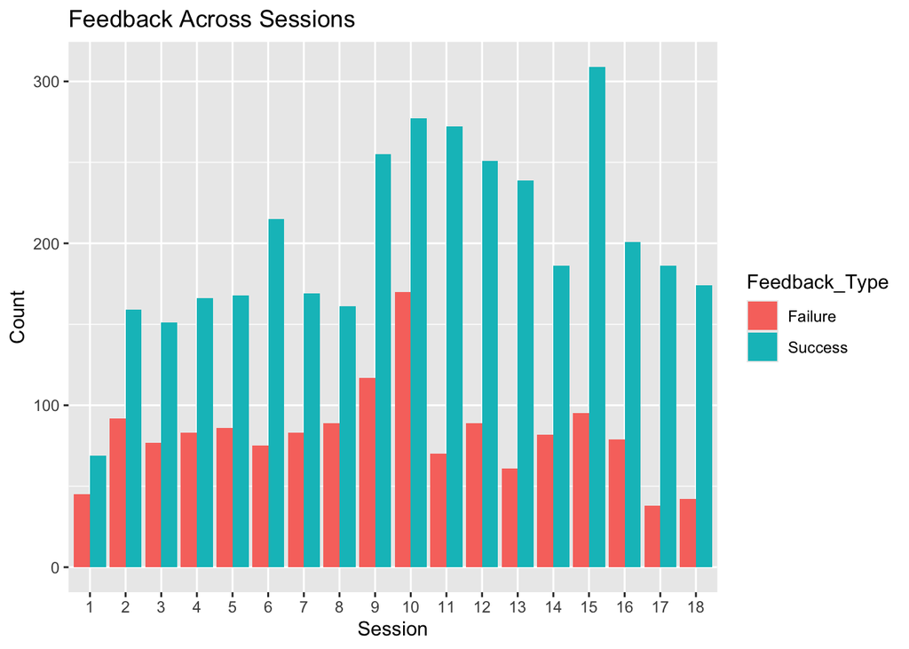

```r
#observing feedback across all sessions
ggplot(feedback_df, aes(x = factor(Session), y = Count, fill = Feedback_Type)) +
  geom_bar(stat = "identity", position = "dodge") +
  labs(title = "Feedback Across Sessions", x = "Session", y = "Count")
```

After assessing some of the other variables, I wanted to look more into spikes per session. I thought it would be useful to create a bar plot to see how many of those spikes that occurred per session were failures vs. successes. From the bar plot above, we can see that there is no specific pattern when it came to count of failures and successes. However, there are points that should be noted. Session 15 had the highest success count, while Session 10 had the highest failure count. Observations can be made for vice versa, where Session 17 had the lowest failure count and Session 1 had the lowest success count.

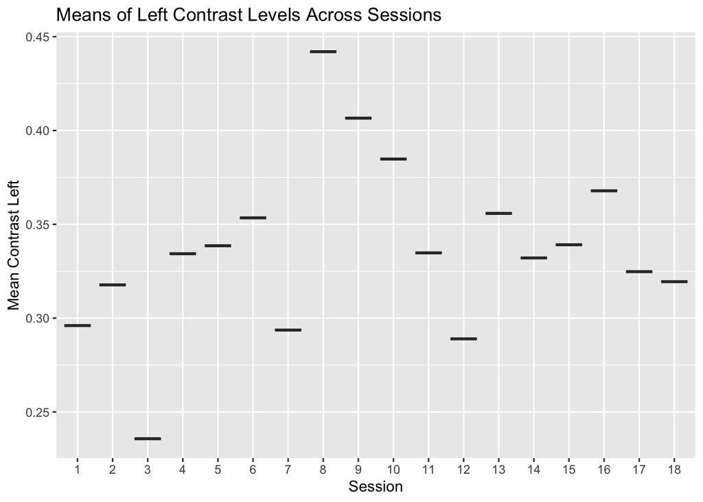

```r
#visualize contrast distribution for left stimulus across sessions
ggplot(contrast_summary_table, aes(x = as.factor(Session), y = Mean_Contrast_Left)) +
  geom_boxplot() +
  labs(title = "Means of Left Contrast Levels Across Sessions", x = "Session", y = "Mean Contrast Left")
```

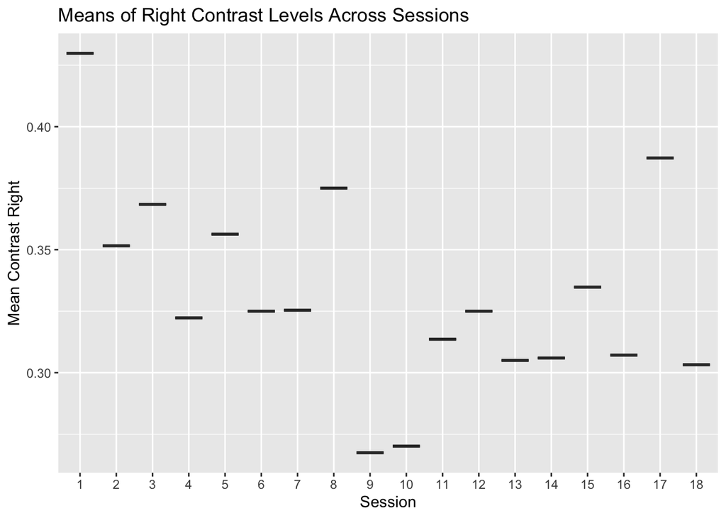

```r
#visualize contrast distribution for right stimulus across sessions
ggplot(contrast_summary_table, aes(x = as.factor(Session), y = Mean_Contrast_Right)) +
  geom_boxplot() +
  labs(title = "Means of Right Contrast Levels Across Sessions", x = "Session", y = "Mean Contrast Right")
```

These two graphs represent the mean contrast levels of the visual stimulus, on both the left and right sides, across all sessions. After exploring all of the dataset’s characteristics, I believe that there might be a strong correlation in decision-making of mice based on spikes and the contrasts. Now that we have explored the characteristics of the data and familiarized ourselves with it, we can now continue the steps that lead us to create a predictive model and see if we can predict the decisions mice make based on neural firing.

# Data Integration

```r
#cleaning, combining, and storing data in order to do pca

session_summary <- list()


for (i in 1:18) {


  total_spks = sum(unlist(session[[i]]$spks), na.rm = TRUE)
  mean_spks = mean(unlist(session[[i]]$spks), na.rm = TRUE)
  min_spks = min(unlist(session[[i]]$spks), na.rm = TRUE)
  max_spks = max(unlist(session[[i]]$spks), na.rm = TRUE)

  mean_contrast_left = mean(session[[i]]$contrast_left, na.rm = TRUE)
  mean_contrast_right = mean(session[[i]]$contrast_right, na.rm = TRUE)


  trial_summary <- data.frame(
    session_number = i,
    total_spks = total_spks,
    mean_spks = mean_spks,
    min_spks = min_spks,
    max_spks = max_spks,
    mean_contrast_left = mean_contrast_left,
    mean_contrast_right = mean_contrast_right
  )


  session_summary[[i]] = trial_summary
}

session_all <- do.call(rbind, session_summary)

print(session_all)
```

After combining our sessions and recalling the necessary statistics, we can do principal component analysis (PCA), which reduces the dimensions of our dataset. By doing this, we are able to reduce the unnecessary parts of out data and visualize the most important parts, which will also assist us in creating our prediction model later.

```r
#do pca to check principal components
numeric_data <- session_all[, sapply(session_all, is.numeric)]
column_variances <- apply(numeric_data, 2, var)
zero_variance_columns <- names(column_variances[column_variances == 0])
print(zero_variance_columns)
```

```
## [1] "min_spks"
```

```r
numeric_data <- numeric_data[, column_variances != 0]

scaled_data <- scale(numeric_data)

pca_result <- prcomp(scaled_data, center = TRUE, scale. = TRUE)

summary(pca_result)
```

```
## Importance of components:
##                           PC1    PC2    PC3     PC4     PC5     PC6
## Standard deviation     1.4191 1.2078 1.1572 0.75684 0.70425 0.34519
## Proportion of Variance 0.3357 0.2432 0.2232 0.09547 0.08266 0.01986
## Cumulative Proportion  0.3357 0.5788 0.8020 0.89748 0.98014 1.00000
```

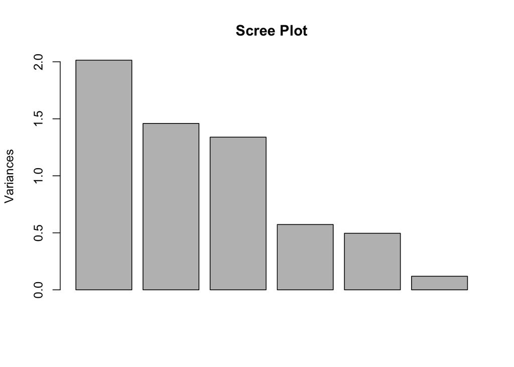

```r
plot(pca_result, main = "Scree Plot")
```

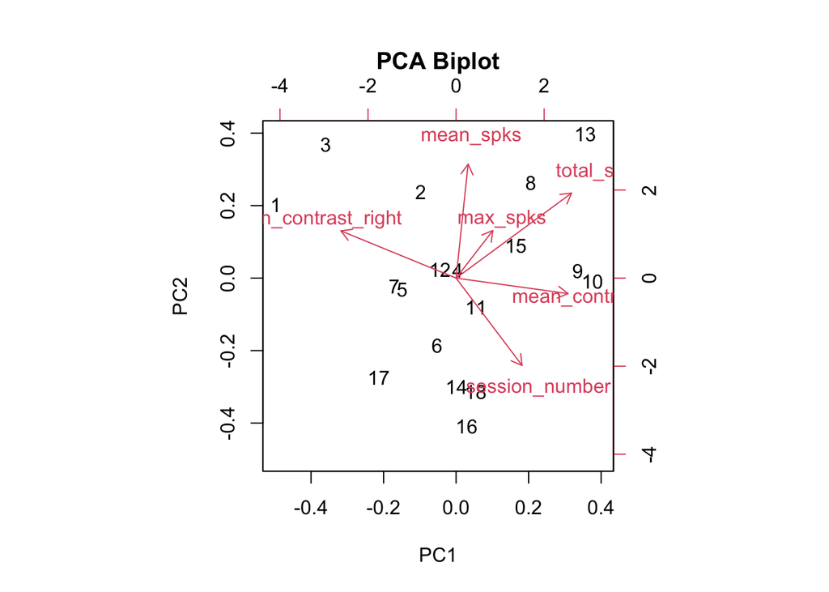

```r
biplot(pca_result, main = "PCA Biplot")
```

After running PCA, we can analyze where the data varies the most, this gives a lead on what to focus on and help us identify any underlying patterns we may not have seen previously when exploring all the sessions. Now, we can further look at the distribution of the proportion of variances that each principal component is responsible for by creating a scree plot.

[figure not shown]

```r
#getting the proportion of variance explained by each principal component and plotting lines for difference visualization
explained_variance <- pca_result$sdev^2 / sum(pca_result$sdev^2)

plot(explained_variance, type = "b",
     main = "Scree Plot of PCA",
     xlab = "Principal Component",
     ylab = "Proportion of Variance Explained",
     pch = 19, col = "blue")

cumulative_variance <- cumsum(explained_variance)
lines(cumulative_variance, type = "b", col = "red", pch = 19)

legend("topright", legend = c("Individual PC", "Cumulative Variance"), col = c("blue", "red"), pch = 19)
```

```r
#focus on two pc's
num_components <- 2
reduced_data <- pca_result$x[, 1:num_components]

loadings <- pca_result$rotation
print("Principal Component Loadings:")
```

```
## [1] "Principal Component Loadings:"
```

```r
print(loadings)
```

```
##                             PC1         PC2        PC3        PC4         PC5
## session_number       0.31104443 -0.48365794  0.3659460 -0.5584652  0.45861593
## total_spks           0.54450633  0.47093270  0.1113626  0.1214307  0.01752170
## mean_spks            0.05677213  0.63165571  0.5055015 -0.2445401  0.05881669
## max_spks             0.17312889  0.26355012 -0.6934428 -0.1338651  0.60117005
## mean_contrast_left   0.52797746 -0.08603015 -0.3090842 -0.4029559 -0.63620459
## mean_contrast_right -0.54296163  0.26162683 -0.1474930 -0.6582386 -0.14051089
##                            PC6
## session_number      -0.1148823
## total_spks          -0.6740039
## mean_spks            0.5282016
## max_spks             0.2009466
## mean_contrast_left   0.2262207
## mean_contrast_right -0.4024532
```

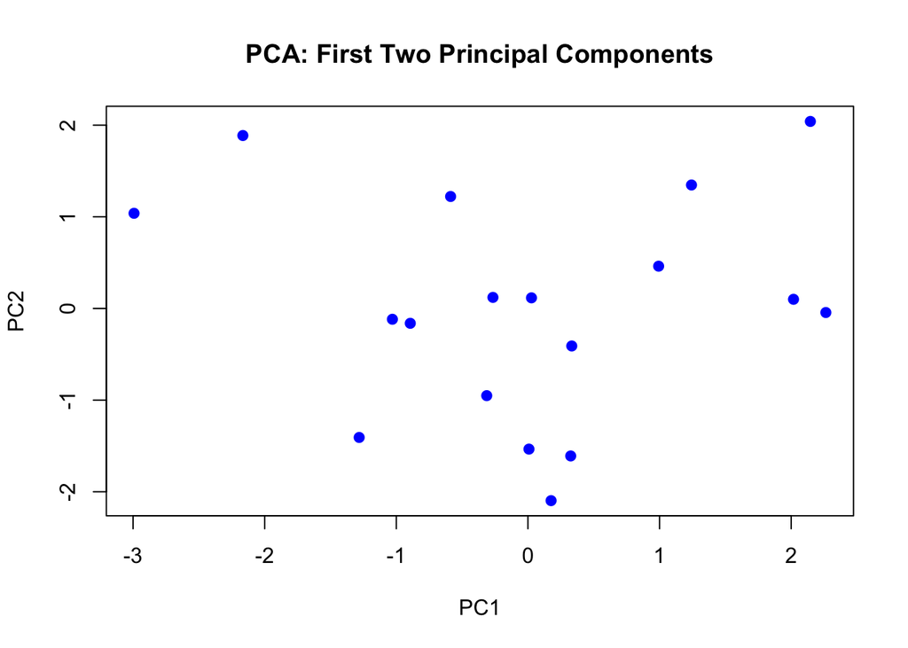

```r
plot(reduced_data[, 1], reduced_data[, 2], col = "blue", pch = 19,
     xlab = "PC1", ylab = "PC2", main = "PCA: First Two Principal Components")
```

We will now focus on the first two principal components (PC1 and PC2), as identified in the previous analysis, and visualize the results. Building upon the insights and data we’ve gathered so far, we will proceed to develop a comprehensive prediction model that integrates all relevant information to improve performance and accuracy.

# Predictive Modeling

Given that we have two possible feedback types—success or failure—we will use a logistic regression model, as it is specifically designed for binary outcomes, allowing us to effectively predict and classify these two distinct feedback types. This model will focus on spks and mean contrasts of left and right, trying to predict the feedback type outcome.

## Model 1

```r
session_summary <- list()

for (i in 1:18) {

  total_spks = sum(unlist(session[[i]]$spks), na.rm = TRUE)
  mean_spks = mean(unlist(session[[i]]$spks), na.rm = TRUE)
  min_spks = min(unlist(session[[i]]$spks), na.rm = TRUE)
  max_spks = max(unlist(session[[i]]$spks), na.rm = TRUE)

  mean_contrast_left = mean(session[[i]]$contrast_left, na.rm = TRUE)
  mean_contrast_right = mean(session[[i]]$contrast_right, na.rm = TRUE)

  #summarize feedback type
  feedback_type = ifelse(session[[i]]$feedback_type == 1, "Success", "Failure")

  #add feedback to trial summary from earlier
  trial_summary <- data.frame(
    session_number = i,
    feedback_type = feedback_type,
    total_spks = total_spks,
    mean_spks = mean_spks,
    min_spks = min_spks,
    max_spks = max_spks,
    mean_contrast_left = mean_contrast_left,
    mean_contrast_right = mean_contrast_right
  )

  session_summary[[i]] = trial_summary
}

session_all <- do.call(rbind, session_summary)

print(head(session_all))

#make success = 1, failure = 0
session_all$feedback_type <- factor(session_all$feedback_type, levels = c("Failure", "Success"))

#logistic regression model predicting success or failure
logistic_model <- glm(feedback_type ~ mean_contrast_left + mean_contrast_right + mean_spks,
                      data = session_all,
                      family = binomial)
summary(logistic_model)

#make predictions using the logistic regression model
predictions <- predict(logistic_model, newdata = session_all, type = "response")
predicted_class <- ifelse(predictions > 0.5, "Success", "Failure")

#confusion matrix
conf_matrix <- table(Predicted = predicted_class, Actual = session_all$feedback_type)

print(conf_matrix)

#calculate accuracy
accuracy <- mean(predicted_class == session_all$feedback_type)
cat("Accuracy of the model:", accuracy, "\n")
```

[output not shown]

After creating Model 1, I realized that I had not considered the importance of brain area in this project. Although I have already gone through multiple steps to observe data and create the first model, I will create a new one that also considers brain area and the spikes in each. Calculating success rate and potentially correlating it to brain area might provide me with a more accurate model.

```r
#calculate success rate for each session
feedback_df <- feedback_df %>%
  group_by(Session) %>%
  mutate(
    Total_Trials = sum(Count),
    Success_Count = Count[Feedback_Type == "Success"],
    Failure_Count = Count[Feedback_Type == "Failure"],
    Success_Rate = Success_Count / Total_Trials
  ) %>%
  ungroup()

brain_area_info <- unlist(lapply(session, function(x) x$brain_area[1]))

feedback_df$Brain_Area <- brain_area_info[feedback_df$Session]

print(feedback_df)
```

```
## # A tibble: 36 × 8
##    Session Feedback_Type Count Total_Trials Success_Count Failure_Count
##      <int> <chr>         <int>        <int>         <int>         <int>
##  1       1 Success          69          114            69            45
##  2       1 Failure          45          114            69            45
##  3       2 Success         159          251           159            92
##  4       2 Failure          92          251           159            92
##  5       3 Success         151          228           151            77
##  6       3 Failure          77          228           151            77
##  7       4 Success         166          249           166            83
##  8       4 Failure          83          249           166            83
##  9       5 Success         168          254           168            86
## 10       5 Failure          86          254           168            86
## # ℹ 26 more rows
## # ℹ 2 more variables: Success_Rate <dbl>, Brain_Area <chr>
```

Above, we now have a table that shows session, feedback type and their counts, total trials, success count, failure count, success rate and brain area, since we can see the success rate for each session and which brain area was recorded. With this information, I can now calculate the mean success rate for each brain area across all sessions.

```r
#calculate the mean success rate for each brain area
brain_area_success <- feedback_df %>%
  group_by(Brain_Area) %>%
  summarize(
    Mean_Success_Rate = mean(Success_Rate, na.rm = TRUE),
    Num_Sessions = n()
  )

#print the mean success rates for each brain area
print(brain_area_success)
```

```
## # A tibble: 18 × 3
##    Brain_Area Mean_Success_Rate Num_Sessions
##    <chr>                  <dbl>        <int>
##  1 ACA                    0.605            2
##  2 AUD                    0.741            2
##  3 BLA                    0.765            2
##  4 CA1                    0.633            2
##  5 CP                     0.806            2
##  6 DG                     0.662            2
##  7 ILA                    0.644            2
##  8 LGd                    0.667            2
##  9 MB                     0.620            2
## 10 MOp                    0.795            2
## 11 ORB                    0.694            2
## 12 SSs                    0.718            2
## 13 TT                     0.685            2
## 14 VISa                   0.661            2
## 15 VISam                  0.797            2
## 16 VISp                   0.738            2
## 17 VPL                    0.671            2
## 18 root                   0.830            2
```

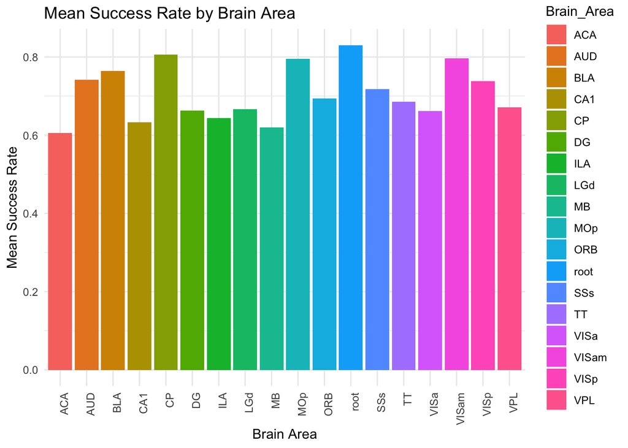

```r
ggplot(brain_area_success, aes(x = Brain_Area, y = Mean_Success_Rate, fill = Brain_Area)) +
  geom_bar(stat = "identity") +
  theme_minimal() +
  labs(
    title = "Mean Success Rate by Brain Area",
    x = "Brain Area",
    y = "Mean Success Rate"
  ) +
  theme(axis.text.x = element_text(angle = 90, hjust = 1))  # Rotate x-axis labels for readability
```

With the table and bar plot, we are able to see which areas have the highest mean success rate, being root, CP, and VISam.

```r
#perform ANOVA to test if success rates differ significantly across brain areas
anova_result <- aov(Success_Rate ~ Brain_Area, data = feedback_df)
summary(anova_result)
```

```
##             Df Sum Sq  Mean Sq   F value Pr(>F)
## Brain_Area  17 0.1628 0.009576 5.335e+29 <2e-16 ***
## Residuals   18 0.0000 0.000000
## ---
## Signif. codes:  0 '***' 0.001 '**' 0.01 '*' 0.05 '.' 0.1 ' ' 1
```

## Model 2

```r
#create another model to see if I can get higher accuracy
session_summary <- list()

for (i in 1:18) {
  total_spks <- sum(unlist(session[[i]]$spks), na.rm = TRUE)
  mean_spks <- mean(unlist(session[[i]]$spks), na.rm = TRUE)
  min_spks <- min(unlist(session[[i]]$spks), na.rm = TRUE)
  max_spks <- max(unlist(session[[i]]$spks), na.rm = TRUE)

  mean_contrast_left <- mean(session[[i]]$contrast_left, na.rm = TRUE)
  mean_contrast_right <- mean(session[[i]]$contrast_right, na.rm = TRUE)

  feedback_type <- ifelse(session[[i]]$feedback_type == 1, 1, 0)

  brain_area <- session[[i]]$brain_area[1]


  trial_summary <- data.frame(
    session_number = i,
    feedback_type = feedback_type,
    total_spks = total_spks,
    mean_spks = mean_spks,
    min_spks = min_spks,
    max_spks = max_spks,
    mean_contrast_left = mean_contrast_left,
    mean_contrast_right = mean_contrast_right,
    brain_area = brain_area  #add brain area to the summary
  )


  session_summary[[i]] <- trial_summary
}

session_all <- do.call(rbind, session_summary)


print(head(session_all))
```

```
##   session_number feedback_type total_spks  mean_spks min_spks max_spks
## 1              1             1     128831 0.03849102        0        6
## 2              1             1     128831 0.03849102        0        6
## 3              1             0     128831 0.03849102        0        6
## 4              1             0     128831 0.03849102        0        6
## 5              1             0     128831 0.03849102        0        6
## 6              1             1     128831 0.03849102        0        6
##   mean_contrast_left mean_contrast_right brain_area
## 1          0.2960526           0.4298246        ACA
## 2          0.2960526           0.4298246        ACA
## 3          0.2960526           0.4298246        ACA
## 4          0.2960526           0.4298246        ACA
## 5          0.2960526           0.4298246        ACA
## 6          0.2960526           0.4298246        ACA
```

```r
#calculate success rate by brain area
brain_area_success <- session_all %>%
  group_by(brain_area) %>%
  summarize(
    success_rate = mean(feedback_type == 1, na.rm = TRUE)
  )


session_all <- session_all %>%
  left_join(brain_area_success, by = "brain_area")


print(head(session_all))
```

```
##   session_number feedback_type total_spks  mean_spks min_spks max_spks
## 1              1             1     128831 0.03849102        0        6
## 2              1             1     128831 0.03849102        0        6
## 3              1             0     128831 0.03849102        0        6
## 4              1             0     128831 0.03849102        0        6
## 5              1             0     128831 0.03849102        0        6
## 6              1             1     128831 0.03849102        0        6
##   mean_contrast_left mean_contrast_right brain_area success_rate
## 1          0.2960526           0.4298246        ACA    0.6052632
## 2          0.2960526           0.4298246        ACA    0.6052632
## 3          0.2960526           0.4298246        ACA    0.6052632
## 4          0.2960526           0.4298246        ACA    0.6052632
## 5          0.2960526           0.4298246        ACA    0.6052632
## 6          0.2960526           0.4298246        ACA    0.6052632
```

```r
logistic_model2 <- glm(feedback_type ~ mean_contrast_left + mean_contrast_right + mean_spks + success_rate,
                      data = session_all,
                      family = binomial)

summary(logistic_model2)
```

```
##
## Call:
## glm(formula = feedback_type ~ mean_contrast_left + mean_contrast_right +
##     mean_spks + success_rate, family = binomial, data = session_all)
##
## Coefficients:
##                     Estimate Std. Error z value Pr(>|z|)
## (Intercept)         -2.73878    0.63908  -4.286 1.82e-05 ***
## mean_contrast_left   0.08197    0.75910   0.108    0.914
## mean_contrast_right  0.16755    0.92199   0.182    0.856
## mean_spks            0.09697    3.03999   0.032    0.975
## success_rate         5.02968    0.50582   9.944  < 2e-16 ***
## ---
## Signif. codes:  0 '***' 0.001 '**' 0.01 '*' 0.05 '.' 0.1 ' ' 1
##
## (Dispersion parameter for binomial family taken to be 1)
##
##     Null deviance: 6118.2  on 5080  degrees of freedom
## Residual deviance: 6011.9  on 5076  degrees of freedom
## AIC: 6021.9
##
## Number of Fisher Scoring iterations: 4
```

```r
library(caret)

predicted_probabilities <- predict(logistic_model, type = "response")

predicted_classes <- ifelse(predicted_probabilities > 0.5, 1, 0)

confusion_matrix <- table(Predicted = predicted_classes, Actual = session_all$feedback_type)
print(confusion_matrix)
```

```
##          Actual
## Predicted    0    1
##         1 1473 3608
```

```r
accuracy <- sum(diag(confusion_matrix)) / sum(confusion_matrix)
print(paste("Accuracy:", accuracy))
```

```
## [1] "Accuracy: 0.289903562290888"
```

# Prediction Performance on Test Sets

## Testing Model 1

```r
setwd("/Users/caitlynnunez/Desktop/sta141a project/test")

session = list()
overview = data.frame(mouse_name = character(), date_exp = character())

for(i in 1:2) {
  session[[i]] = readRDS(paste("test", i, ".rds", sep=''))

  overview = rbind(overview, data.frame(mouse_name = session[[i]]$mouse_name, date_exp = session[[i]]$date_exp))
}
```

The test data will be from the mice Cori and Lederberg, where the first test comes from Session 1 and the second comes from Session 18.

```r
#preparing test data just incase of error

setwd("/Users/caitlynnunez/Desktop/sta141a project/test")

session = list()
overview = data.frame(mouse_name = character(), date_exp = character())

for(i in 1:2) {  # Loop through test1 and test2 only
  session[[i]] = readRDS(paste("test", i, ".rds", sep=''))


  overview = rbind(overview, data.frame(mouse_name = session[[i]]$mouse_name, date_exp = session[[i]]$date_exp))
}


print(overview)
```

```
##   mouse_name   date_exp
## 1       Cori 2016-12-14
## 2  Lederberg 2017-12-11
```

```r
prepare_trial_data <- function(session_data) {
  trial_data = data.frame(
    feedback_type = unlist(lapply(session_data$feedback_type, function(x) x)),
    contrast_left = unlist(lapply(session_data$contrast_left, function(x) x)),
    contrast_right = unlist(lapply(session_data$contrast_right, function(x) x)),
    time = unlist(lapply(session_data$time, function(x) x)),
    spks = unlist(lapply(session_data$spks, function(x) x)),
    brain_area = unlist(lapply(session_data$brain_area, function(x) x))
  )

  return(trial_data)
}

test1_data <- prepare_trial_data(session[[1]])

test2_data <- prepare_trial_data(session[[2]])

test1_data$brain_area <- as.factor(test1_data$brain_area)
test2_data$brain_area <- as.factor(test2_data$brain_area)

test1_data <- cbind(test1_data, model.matrix(~ brain_area - 1, data = test1_data))
test2_data <- cbind(test2_data, model.matrix(~ brain_area - 1, data = test2_data))
```

## Test 1 on Model

```r
setwd("/Users/caitlynnunez/Desktop/sta141a project/test")

#applying test 1 to my logistical regression model
test1 <- readRDS("test1.rds")

session_summary <- list()

for (i in 1:1) {

  total_spks = sum(unlist(test1$spks), na.rm = TRUE)
  mean_spks = mean(unlist(test1$spks), na.rm = TRUE)
  min_spks = min(unlist(test1$spks), na.rm = TRUE)
  max_spks = max(unlist(test1$spks), na.rm = TRUE)

  mean_contrast_left = mean(test1$contrast_left, na.rm = TRUE)
  mean_contrast_right = mean(test1$contrast_right, na.rm = TRUE)


  feedback_type = ifelse(test1$feedback_type == 1, "Success", "Failure")


  trial_summary <- data.frame(
    session_number = i,
    feedback_type = feedback_type,
    total_spks = total_spks,
    mean_spks = mean_spks,
    min_spks = min_spks,
    max_spks = max_spks,
    mean_contrast_left = mean_contrast_left,
    mean_contrast_right = mean_contrast_right
  )

  session_summary[[i]] = trial_summary
}

session_all <- do.call(rbind, session_summary)

print(head(session_all))
```

```
##   session_number feedback_type total_spks  mean_spks min_spks max_spks
## 1              1       Failure     111867 0.03810184        0        6
## 2              1       Success     111867 0.03810184        0        6
## 3              1       Success     111867 0.03810184        0        6
## 4              1       Success     111867 0.03810184        0        6
## 5              1       Success     111867 0.03810184        0        6
## 6              1       Success     111867 0.03810184        0        6
##   mean_contrast_left mean_contrast_right
## 1             0.3075              0.3975
## 2             0.3075              0.3975
## 3             0.3075              0.3975
## 4             0.3075              0.3975
## 5             0.3075              0.3975
## 6             0.3075              0.3975
```

```r
session_all$feedback_type <- factor(session_all$feedback_type, levels = c("Failure", "Success"))


logistic_modeltest1 <- glm(feedback_type ~ mean_contrast_left + mean_contrast_right + mean_spks,
                      data = session_all,
                      family = binomial)

summary(logistic_modeltest1)
```

```
##
## Call:
## glm(formula = feedback_type ~ mean_contrast_left + mean_contrast_right +
##     mean_spks, family = binomial, data = session_all)
##
## Coefficients: (3 not defined because of singularities)
##                     Estimate Std. Error z value Pr(>|z|)
## (Intercept)           0.9445     0.2227   4.241 2.23e-05 ***
## mean_contrast_left        NA         NA      NA       NA
## mean_contrast_right       NA         NA      NA       NA
## mean_spks                 NA         NA      NA       NA
## ---
## Signif. codes:  0 '***' 0.001 '**' 0.01 '*' 0.05 '.' 0.1 ' ' 1
##
## (Dispersion parameter for binomial family taken to be 1)
##
##     Null deviance: 118.59  on 99  degrees of freedom
## Residual deviance: 118.59  on 99  degrees of freedom
## AIC: 120.59
##
## Number of Fisher Scoring iterations: 4
```

```r
predictions_prob <- predict(logistic_modeltest1, session_all, type = "response")

predictions_class <- ifelse(predictions_prob > 0.5, "Success", "Failure")

confusion_matrix <- table(Predicted = predictions_class, Actual = session_all$feedback_type)
print(confusion_matrix)
```

```
##          Actual
## Predicted Failure Success
##   Success      28      72
```

```r
accuracy <- sum(diag(confusion_matrix)) / sum(confusion_matrix)
cat("Model Accuracy:", accuracy, "\n")
```

```
## Model Accuracy: 0.28
```

## Test 2 with Model

```r
setwd("/Users/caitlynnunez/Desktop/sta141a project/test")

test2 <- readRDS("test2.rds")

session_summary <- list()

for (i in 1:1) {

  total_spks = sum(unlist(test2$spks), na.rm = TRUE)
  mean_spks = mean(unlist(test2$spks), na.rm = TRUE)
  min_spks = min(unlist(test2$spks), na.rm = TRUE)
  max_spks = max(unlist(test2$spks), na.rm = TRUE)

  mean_contrast_left = mean(test2$contrast_left, na.rm = TRUE)
  mean_contrast_right = mean(test2$contrast_right, na.rm = TRUE)

  feedback_type = ifelse(test2$feedback_type == 1, "Success", "Failure")

  trial_summary <- data.frame(
    session_number = i,
    feedback_type = feedback_type,
    total_spks = total_spks,
    mean_spks = mean_spks,
    min_spks = min_spks,
    max_spks = max_spks,
    mean_contrast_left = mean_contrast_left,
    mean_contrast_right = mean_contrast_right
  )

  session_summary[[i]] = trial_summary
}

session_all <- do.call(rbind, session_summary)


session_all$feedback_type <- factor(session_all$feedback_type, levels = c("Failure", "Success"))


logistic_modeltest2 <- glm(feedback_type ~ mean_contrast_left + mean_contrast_right + mean_spks,
                           data = session_all,
                           family = binomial)

summary(logistic_modeltest2)

predictions_prob <- predict(logistic_modeltest2, session_all, type = "response")

predictions_class <- ifelse(predictions_prob > 0.5, "Success", "Failure")

confusion_matrix <- table(Predicted = predictions_class, Actual = session_all$feedback_type)
print("Confusion Matrix:")
print(confusion_matrix)

accuracy <- sum(diag(confusion_matrix)) / sum(confusion_matrix)
cat("Model Accuracy:", accuracy, "\n")
```

[output not shown]

# Discussion

In reflecting on the performance of my model, it is evident that there are several areas where it fell short of expectations. The results, as demonstrated by the confusion matrix and the overall model performance, indicate that the model’s predictive power was limited, with potential issues related to feature selection, data preprocessing, and model tuning or selection. This could have been a result of not fully applying the skills and knowledge I have gained from other courses, as well as from this one, in a correct manner. For example, looking at my code and data I have gathered, I could have better handled imbalanced data, which might have led to improved performance. Additionally, I could have focused more on fine-tuning the logistic regression model or explored other algorithms that might be better suited for the dataset. Overall, this experience highlights areas for growth in terms of model development, and I recognize that with further practice and a more holistic application of the skills I have acquired, I could build a more effective model in the future.

# References

Steinmetz, N.A., Zatka-Haas, P., Carandini, M. et al. Distributed coding of choice, action and engagement across the mouse brain. Nature 576, 266–273 (2019). https://doi.org/10.1038/s41586-019-1787-x

ChatGPT for checking for errors and correct application

Material I referenced for assistance from other STA courses I have taken such as, STA108, STA106, STA104, etc.